# FinalProject

Uyen Dang, Roshan Mettupalli, Josh Williams, Mo Young

2023-12-08

# Introduction

Many individuals have heard the saying “happy people live longer”, a notion that resonates with the broader discourse on the intricate relationship between well-being and longevity. In recent years, the intersection of well-being and public health has become a focal point of global discussions. Specifically, over the last 50 years, life expectancy globally has increased about 10-15 years. The pursuit of happiness and a fulfilling life is a universal human aspiration, and its connection with various socio-economic factors has intrigued researchers, policymakers, and the general public alike. To further analyze this, our group project ultimately aims to explore the relationship between a country’s happiness score and its life expectancy, while focusing specifically on data from the year 2015. Happiness and life expectancy are variables that are thought to usually go hand-in-hand, though the research on its association is limited due to the complex interplay of multifaceted determinants , thus, warrants our interest in this topic.

The intertwining dynamics of happiness and life expectancy present a multidimensional lens through which we can understand the complex nature of human well-being. As nations strive to enhance the quality of life for their citizens, understanding the factors that contribute to happiness becomes crucial. Our investigation is joined by different countries’ happiness scores and their life expectancy, along with other variables to widen our research and understanding. We aim to create a comprehensive assessment of happiness levels worldwide, while hoping to provide a unique dataset that allows for a nuanced exploration of the links between subjective well-being and one of the most fundamental indicators of public health – life expectancy.

The relationship between happiness and health has been emphasized in published works of literature and media coverage. Many studies indicate that having a positive emotional state may contribute to better health outcomes, mentally and physically. Nonetheless, further research is needed to determine the precise relationship between happiness and life expectancy. To unravel the intricacies of these variables, our project proposes four questions that act as a source of guidance throughout our analysis.

### Research questions

1. How strongly does the happiness score in a specific country correlate with its life expectancy, and what trends or patterns emerge from this relationship?
2. To what extent do socio-economic factors, such as GDP and population, influence the connection between happiness scores and life expectancy across diverse countries?
3. How does the happiness rank of a country correlate with its life expectancy, and are there notable variations among countries with similar happiness scores but different life expectancies?
4. Can the status of a country (e.g., developed or developing) act as a moderating factor in the relationship between happiness scores and life expectancy?

### Significance

Understanding the intricate connection between happiness and life expectancy has far-reaching implications for policymakers, public health professionals, and the general public. By unraveling the underlying factors that contribute to well-being, this analysis could provide valuable insights into targeted interventions that promote happiness and, by extension, healthier societies as country leaders are envisioning a better tomorrow for their citizens. Furthermore, the findings of this study could contribute to the ongoing discourse on holistic development, emphasizing the importance of considering both subjective and objective indicators in shaping comprehensive public policies. As such, this report is a compelling exploration of the interplay between happiness and life expectancy, offering potential avenues for fostering improved societal well-being. From a public health perspective, the findings of this analysis could offer actionable insights for policymakers, healthcare practitioners, and community leaders. Strategies that prioritize not only the treatment of diseases but also the enhancement of societal well-being are essential for fostering resilient, thriving communities. As the world continues to grapple with unprecedented health challenges, this project contributes to the broader conversation on redefining health outcomes, placing happiness and life expectancy at the forefront of a comprehensive public health agenda.

# Explain your data

### Why do you use these datasets?

- Life Expectancy Dataset: We chose this dataset because it contains health data of most of the countries of the world. It also contains economic data, so it was interesting to see the correlation between economy and health data. One of the more important reasons for why we chose this dataset was because it contained a country column that contained a lot of countries similar to the Happiness dataset. This country column was able to act like a “primary key”. Lastly, this dataset contained data from the 2000’s to 2015, and our research question primarily focused on data from 2015.
- Happiness Dataset: We chose this dataset because it contains information on happiness. To be specific, this dataset looked at multiple factors related to happiness such as social support, corruption perception, freedom, and more. Also, this dataset contained a country column similar to the Life Expectancy Data, so the country column in the Happiness Dataset was able to act similarly to a “foreign key” to connect our data to the Life Expectancy Dataset. Lastly, this dataset contained updated data for 2015, which was perfect because the life expectancy dataset also contained data from 2015. We wanted our data to be consistent so it was very important that both datasets had data from the same year.

### Where do your datasets originate from?

- Life Expectancy Dataset: We got this data from Kaggle, but the dataset for Life Expectancy originated from the Global Health Observatory (GHO) data repository under the World Health Organization.
- Happiness Dataset: We got his data from Kaggle, but it was originally from the Gallup World Poll.

### Who collected the data?

- Life Expectancy Dataset: The health data from the data set was collected by the World Health Organization. Meanwhile, the economic data was collected by the United Nations.
- Happiness Dataset: This data was primarily collected by the Gallup World Poll, but some of the data was collected from World Health Organization, World Development Indicators, and other other published journal articles. The data was then prepared and researched through the help of these universities: Sustainable Development (Columbia University), Centre of Economic Performance (London School of Economics), Vancouver School of Economics (University of British Columbia), Wellbeing Research Centre (University of Oxford), and the Helping and Happiness Lab (Simon Fraser University).

### The data usage permissions

- Life Expectancy Dataset: The data is publicly available meaning that anyone can access it. The purpose of this data is for health data analysis.
- Happiness Dataset: This data is publically available. The main purpose of this data is to help the Sustainable Development Solutions Network of the United Nations, but it could be used by anyone.

### What are the datasets about? What is the population and what is the sample?

- Life Expectancy Dataset: This dataset focuses primarily on immunization, mortality, economic, social, and other health related factors for most countries in the world. I wasn’t able to track down the original datasets from WHO (because they have so much data), but I’m assuming the population is all the countries looked at in the dataset. As of sample, since I couldn’t find the original dataset’s info, I am unable to supply anything on sample.
- Happiness Dataset: This data set focuses on multiple factors that relate to happiness on an international scale. Contents include happiness rank, happiness score, economy (GDP), family, health (life expectancy), freedom, trust (gov corruption), generosity, and more. The population of this dataset includes most countries of the world. The sample of this dataset aims to have 2000+ people per country to have a large enough sample size to reduce random sampling errors. It has a 95% confidence interval.

### Discuss any data quality issues you encountered.

- Life Expectancy Dataset: A data quality issue that we encountered in this dataset was that there were a few NA values. Also something to note according to the author of this dataset on Kaggle was that less known countries that didn’t have enough information were excluded from the dataset such as Tonga, Togo, and Cabo Verde.
- Happiness Dataset: Some countries with this dataset didn’t align with the Life Expectancy data, so those countries were excluded. Some things to note from the World Happiness Report, which is the website that includes all the information about this data, is that there were a few out of date data (data not from updated to 2015) at the time when they were collecting and creating this dataset. For these data, they mixed other related up-to-date data with mathematical calculations to infer these values.

### What do rows represent in your final dataset?

- In our final dataset, rows represent each country in the year 2015, and their corresponding happiness and life expectancy statistics.

### How many observations do you have?

- We have 135 observations.

### What are the relevant variables and how are they coded?

- The relevant variables are country, year, status, life expectancy, GDP, population, happiness rank, happiness score, standard error, happiness category, and maximum happiness. Country, status, and happiness category are coded as characters, whereas the rest are coded as numeric variables. Our first created variable was happiness category, which was coded as the top 10 being Category A, 11-50 being Category B, 51-100 being Category C, and the remaining being Category D. Our other created variable was maximum happiness, which was coded as the happiness score added to the standard error to represent the maximum happiness score possible for each country. The remaining variables were all collected from the two data sets.

### Are there any missing, non-plausible values, or other quality issues in the relevant variables? How many?

- There are 18 missing values in the relevant variables.

### What are the original data sources

- Life expectancy data: https://www.kaggle.com/datasets/kumarajarshi/life-expectancy-who
- Happiness data: https://www.kaggle.com/datasets/unsdsn/world-happiness

### Explanation of all variables you include here

- Country: each country being used for its happiness and life expectancy statistics, the observational unit of this study
- Year: 2015 data for all countries
- Status: status as a country, either developed or developing
- Life expectancy: the amount of years that a person in that country is expected to live
- GDP: the gross domestic product, which is used to measure each country’s economy
- Population: the total number of people living in a country
- Happiness rank: the country’s worldwide rank in happiness score
- Happiness score: surveyed from each country by asking “How would you rate your happiness on a scale of 0-10”, this statistic is the average score per country
- Standard error: the standard error of the happiness score, statistically is the standard deviation of the sampling distribution
- Happiness category: category by happiness score, the top 10 are Category A, 11-50 are Category B, 51-100 are Category C, and the remaining are Category D
- Maximum happiness: computed by adding the happiness score to the standard error

### Basic summary statistics

- Number of Rows: 135
- Number of Columns: 11
- Number of Missing (Country): 0
- Number of Missing (Year): 0
- Number of Missing (Status): 0
- Number of Missing (Life Expectancy): 0
- Number of Missing (GDP): 5
- Number of Missing (Population): 13
- Number of Missing (Happiness Rank): 0
- Number of Missing (Happiness Score): 0
- Number of Missing (Standard Error): 0
- Number of Missing (Happiness Category): 0
- Number of Missing (Maximum Happiness): 0

# Methods

### Which variables did you include?

The following variables were included in our analysis to explore the relationship between happiness and life expectancy:

1. Country: The observational unit of the study.
2. Year: Limited to 2015 for consistency in data.
3. Status: Indicates whether a country is developed or developing.
4. Life Expectancy: Fundamental to our investigation.
5. GDP: Reflects a country’s economic status.
6. Population: Provides insight into the size of the country.
7. Happiness Rank and Score: Key indicators of subjective well-being.
8. Standard Error: Represents the uncertainty in the happiness score.
9. Happiness Category: Categorized based on rank.
10. Maximum Happiness: Calculated as the sum of happiness score and standard error, representing the highest possible happiness score for each country.

We decided to choose these variables in order to capture factors while considering well-being, economy, social, and health dimensions. The inclusion of status, GDP, and population allows for an exploration of socioeconomic influences on the happiness-life expectancy relationship.

### How did you process your data?

```
## # A tibble: 183 × 19
##    Country      Year Status `Life expectancy ` `Adult Mortality` `infant deaths`
##    <chr>       <dbl> <chr>               <dbl>             <dbl>           <dbl>
##  1 Afghanistan  2015 Devel…               65                 263              62
##  2 Albania      2015 Devel…               77.8                74               0
##  3 Algeria      2015 Devel…               75.6                19              21
##  4 Angola       2015 Devel…               52.4               335              66
##  5 Antigua an…  2015 Devel…               76.4                13               0
##  6 Argentina    2015 Devel…               76.3               116               8
##  7 Armenia      2015 Devel…               74.8               118               1
##  8 Australia    2015 Devel…               82.8                59               1
##  9 Austria      2015 Devel…               81.5                65               0
## 10 Azerbaijan   2015 Devel…               72.7               118               5
## # ℹ 173 more rows
## # ℹ 13 more variables: `Hepatitis B` <dbl>, `Measles ` <dbl>, ` BMI ` <dbl>,
## #   `under-five deaths ` <dbl>, Polio <dbl>, `Diphtheria ` <dbl>,
## #   ` HIV/AIDS` <dbl>, GDP <dbl>, Population <dbl>,
## #   ` thinness  1-19 years` <dbl>, ` thinness 5-9 years` <dbl>,
## #   `Income composition of resources` <dbl>, Schooling <dbl>
```

- Life Expectancy Dataset has been read and filtered for the year 2015. Some columns (Alcohol, Total expenditure, percentage expenditure) were excluded

```
## # A tibble: 158 × 11
##    Country     Region        `Happiness Rank` `Happiness Score` `Standard Error`
##    <chr>       <chr>                    <dbl>             <dbl>            <dbl>
##  1 Switzerland Western Euro…                1              7.59           0.0341
##  2 Iceland     Western Euro…                2              7.56           0.0488
##  3 Denmark     Western Euro…                3              7.53           0.0333
##  4 Norway      Western Euro…                4              7.52           0.0388
##  5 Canada      North America                5              7.43           0.0355
##  6 Finland     Western Euro…                6              7.41           0.0314
##  7 Netherlands Western Euro…                7              7.38           0.0280
##  8 Sweden      Western Euro…                8              7.36           0.0316
##  9 New Zealand Australia an…                9              7.29           0.0337
## 10 Australia   Australia an…               10              7.28           0.0408
## # ℹ 148 more rows
## # ℹ 6 more variables: `Economy (GDP per Capita)` <dbl>, Family <dbl>,
## #   Freedom <dbl>, `Trust (Government Corruption)` <dbl>, Generosity <dbl>,
## #   `Dystopia Residual` <dbl>
```

- Happiness Dataset has been read and filtered
- “mergedData” is made based on “Country” column and uses inner join to merge “le” and “happy” datasets
- “happiness_category” is our newly created categorical column based on happiness rank
- “maximum_happiness” is our newly added numerical column which was created by adding happiness score and standard error

```
## Life Expectancy Summary:
```

```
##    Min. 1st Qu.  Median    Mean 3rd Qu.    Max.
##   51.00   66.05   74.50   72.07   77.55   88.00
```

```
## Maximum Happiness Summary:
```

```
##    Min. 1st Qu.  Median    Mean 3rd Qu.    Max.
##   2.906   4.582   5.244   5.432   6.342   7.621
```

- prints basic summary statistics of newly created merged data set

### How did you select your sample?

- We selected our sample by filtering it by the year 2015. This was because the availability of data was good for this year. We aimed to analyze and represent all the countries worldwide, considering developed and developing nations. After cleaning and merging out data, we were left with 135 observations.

### Technical Decisions

- Handling Missing Values: Identified and addressed missing values in GDP and population. A total of 18 missing values were observed
- Categorical Variables: Created categorical variables such as “happiness_category” to facilitate analysis and interpretation
- Graphical Representations: Utilized scatter plots with trend lines to visually explore relationships between variables

### Statistical Methods

- Correlation Analysis: Utilized scatter plots and trend lines to visually assess the strength and direction of relationships, especially between happiness score and life expectancy
- Moderation Analysis: Examined the influence of the country’s development status on the relationship between happiness scores and life expectancy using a scatter plot with trend lines for developed and developing countries
- Graphical Visualization: Incorporated graphical representations for a more intuitive interpretation of the results, including scatter plots with color gradients for GDP and population

# Results

To answer our four research questions, we created graphs to visualize the impacts of each relationship to ultimately show if there is an association between the variables. The results can be broken down into each question below:

### 1. How strongly does the happiness score in a specific country correlate with its life expectancy, and what trends or patterns emerge from this relationship?

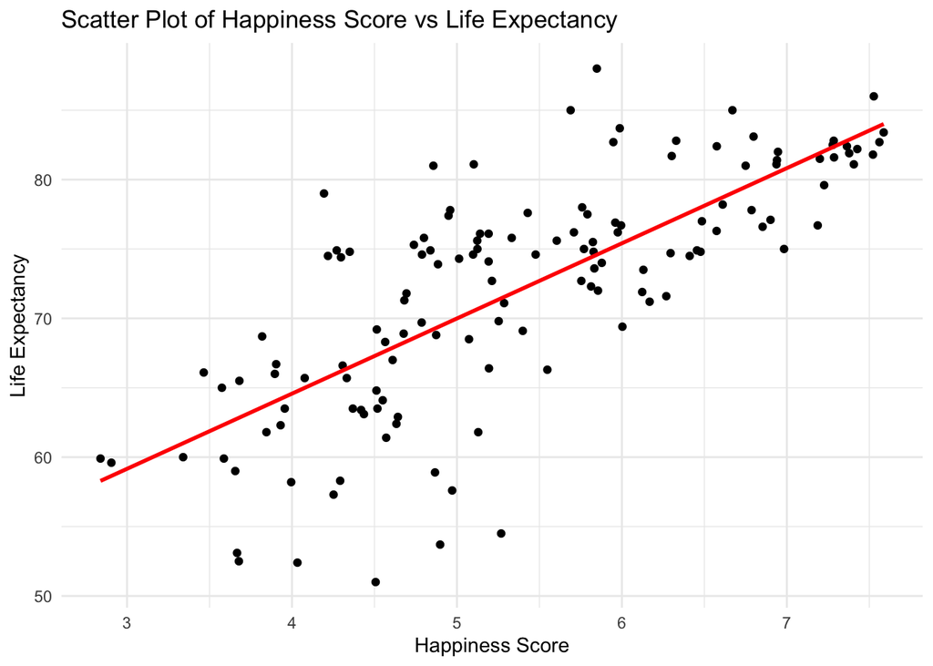

- Happiness score in a specific country correlates with its life expectancy in a linearly positive trend. This is shown through the line of best fit, which has a very positive slope and shows a distinct correlation in that higher life expectancies are correlated with higher happiness scores and lower life expectancies are correlated with lower happiness scores.

### 2. To what extent do socio-economic factors, such as GDP and population, influence the connection between happiness scores and life expectancy across diverse countries?

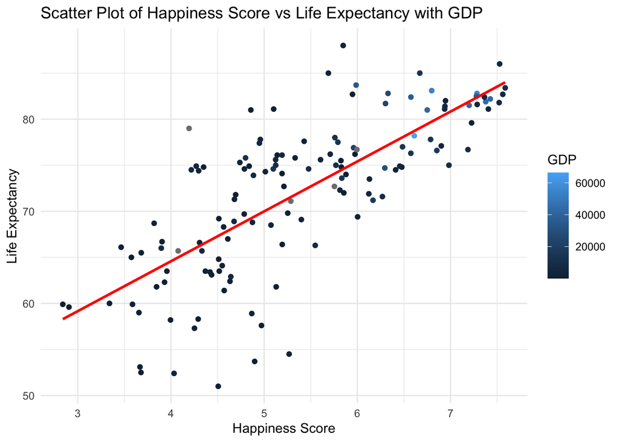

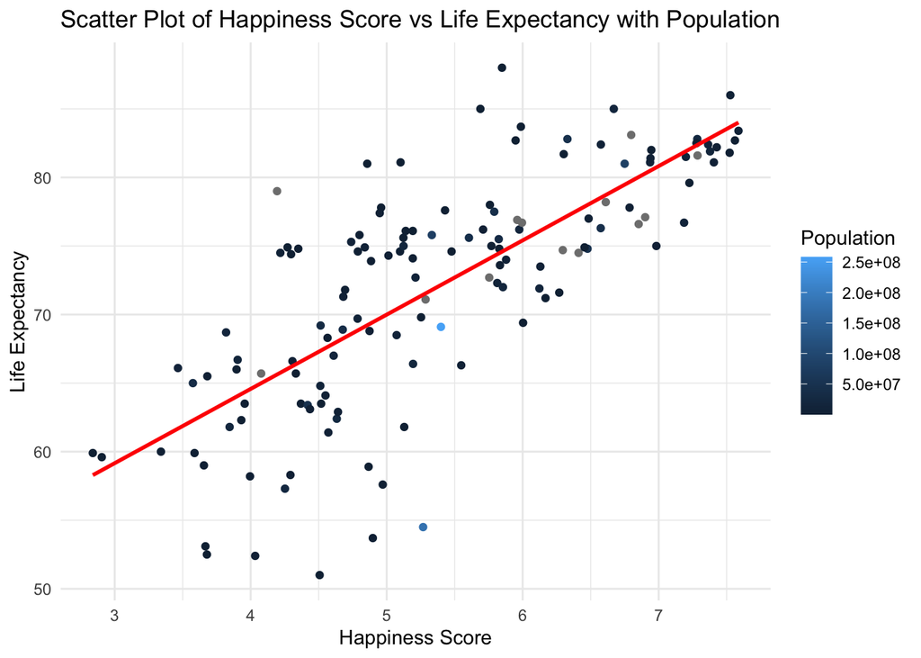

- According to our graph, GDP does not appear to have much of an extreme influence on the relationship between happiness scores and life expectancy, but a slight trend can be identified in that countries with greater GDPs tend to have greater life expectancies and greater happiness scores, and the opposite tendencies for countries with lower GDPs. On the other hand, population also does not appear to have much of an influence on this statistical relationship, as there is a great variation in how countries of similar populations rank amongst each other in terms of their life expectancy vs happiness score, and a clear trend cannot be identified.

### 3. How does the happiness rank of a country correlate with its life expectancy, and are there notable variations among countries with similar happiness scores but different life expectancies?

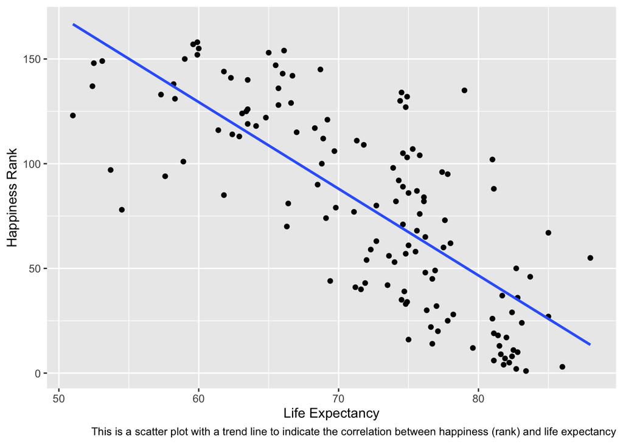

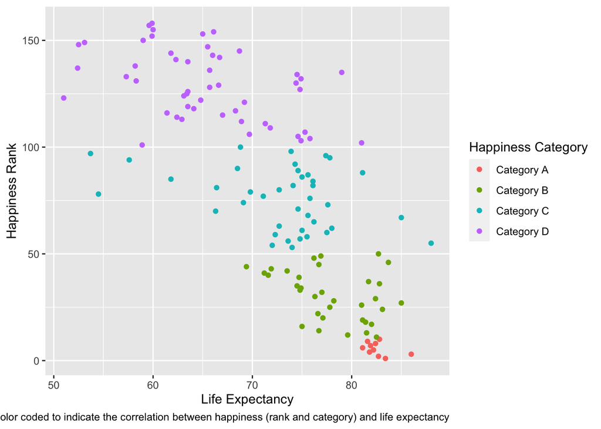

### 4. Can the status of a country (e.g., developed or developing) act as a moderating factor in the relationship between happiness scores and life expectancy?

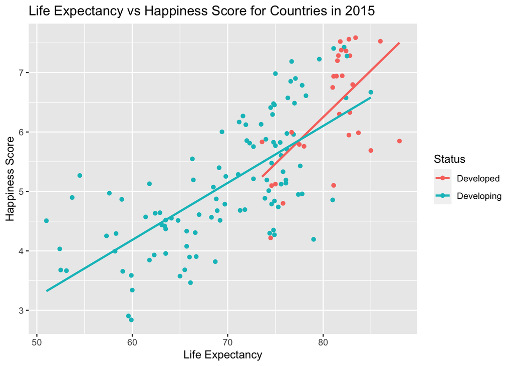

# Discuss Findings

The results of our project tells us that overall, there is a positive relationship between happiness score and life expectancy, while also accounting for other factors mentioned in our research questions.

As shown in “Scatter Plot of Happiness Score vs Life Expectancy”, the variable Happiness Score is on x-axis, while Life Expectancy is on the y-axis, with a best-fit line showing a linearly positive relationship between the two variables. This suggests that, on average, as the Happiness Score of a specific country increases, its Life Expectancy also tends to increase. This finding aligns with the notion that subjective well-being, as measured by happiness in this case, may contribute positively to overall health outcomes. From a public perspective, these implications urge considerations for strategies that not only address healthcare but also encompass broader factors influencing happiness. Initiatives promoting social support, mental health, and community engagement may become integral to enhancing both happiness and life expectancy. Moreover, the positive relationship prompts reflections on the potential universality of the connection between happiness and life expectancy, contributing to a broader understanding of global wellbeing.

In our “Scatter Plot of Happiness Score vs Life Expectancy with Population” and “Scatter Plot of Happiness Score vs Life Expectancy with GDP”, the same positive trend and association shown in the previous plot are shown, but with specific gradient colors denoting GDP and population levels. In the GDP focused plot, there is a good amount of countries with high GDP having a higher life expectancy and happiness score. This suggests that a positive association between economic prosperity, as reflected in the country’s GDP, and the wellbeing indicators of life expectancy and happiness. Conversely, in the Population focused scatter plot, the interpretation is less straightforward. The varied gradient colors based on population sizes make it more challenging for us to draw a clear and significant connection between population and a country’s happiness score and life expectancy. Unlike the evident trend observed with GDP, the impact of population on these well-being indicators appears less pronounced. From a socio-economic perspective, these findings suggest that economic prosperity, as measured by GDP per capita, may play a more substantial role in influencing the connection between happiness scores and life expectancy across diverse countries. The positive correlation observed in the GDP-focused plot implies that as a country’s economic status improves, there is a concurrent improvement in both life expectancy and happiness. However, the nuanced and less distinct findings in the population-focused graph suggest that the influence of population size on these well-being indicators is not as straightforward as we initially thought.

Lastly, the “Life Expectancy vs Happiness Score for Countries in 2015” scatter plot showed two best-fit lines for developing and developed countries. The results indicate that the status of a country, whether developed or developing, acts as a moderating factor in the relationship between happiness scores and life expectancy. The observed distinction in the best-fit lines for developed and developing countries in the scatter plot suggests that economic development levels influence the nature and strength of this relationship. Developed countries exhibit a steeper relationship line, implying a more pronounced association between happiness scores and life expectancy, while developing countries show a more gradual increase line, suggesting a gentler correlation. This underscores the importance of considering a country’s development status when examining the complex interplay between subjective well-being and life expectancy.

While the analysis provides valuable insights into the relationships between happiness scores, life expectancy, and socio-economic factors across countries, several limitations should be acknowledged. The cross-sectional nature of the data from the year 2015 restricts the ability to establish causal relationships or capture temporal dynamics. Additionally, the simplification of dividing countries into categories: developed and developing may oversimplify the complex realities of diverse nations. Furthermore, the study does not delve deeply into specific cultural, political, or healthcare system factors that could contribute to variations in the observed relationships.

To extend the story, future work should involve longitudinal data to explore trends over time and assess causality. More detailed socio-cultural analyses and consideration of additional variables, such as healthcare infrastructure and political stability, would provide a more comprehensive understanding of the observed patterns. Additionally, qualitative research methods could offer insights into the contextual nuances influencing well-being. As stated in the introduction, there are many factors that obviously play into a country’s life expectancy and happiness, and this project does not aim to prove its true association. Our mere goal was to see if there was a close enough relationship between the two. Further, some missing or removed data might make this conclusion harder to draw.

# Summary and Conclusion

In our comprehensive exploration of the intricate relationship between happiness and life expectancy across countries, our analysis uncovers some compelling insights and prompts considerations for public health and policy interventions. The overarching theme is that there is a positive correlation between a country’s happiness score and its life expectancy. This is evidenced by the linearly positive relationship depicted in the scatter plot of Happiness Score vs Life Expectancy, suggesting that as a country’s happiness score increases, so does its life expectancy. This finding aligns with current research and literature, ultimately supporting the known belief that a balanced and happy state positively contributes to a person’s health outcomes. Beyond this connection, economic prosperity, as indicated by GDP, is correlated with higher life expectancy and happiness. The development status of a country moderates the happiness-life expectancy relationship, with developed nations showing a more pronounced correlation. While our insights offer valuable considerations for public health, acknowledging limitations, future work should explore longitudinal data and socio-cultural nuances for a more comprehensive understanding.

To revisit, our topic is inherently multidimensional and encompasses a myriad of interconnected factors that contribute to the complexity of understanding the dynamics at play. As a result of our findings, we came to the conclusion that social science questions such as “does happiness affect life expectancy” introduces challenges rooted in the subjective nature of wellbeing and doesn’t take into account different factors and determinants. Happiness itself is a nuanced and subjective experience, varying across individuals and cultures, making it difficult to quantify in a standardized manner. Moreover, life expectancy is influenced by an array of factors, ranging from socio-economic conditions to healthcare accessibility. Attempting to distill these multifaceted elements into quantifiable measures requires careful consideration of various dimensions, acknowledging the limitations and potential biases inherent in such assessments. Thus, the pursuit of unraveling the intricate connections between happiness and life expectancy underscores the intricate nature of social science inquiries and the ongoing quest to capture the nuanced realities of human well-being.